# Google Data Analytics Capstone - Case Study 1

Assim Alharbi

2024-03-07

# Case Study

This is a case study from the Google Data Analytics Certificate, it is considered to be one of the final comprehensive projects to complete the certificate.

The goal of this case study is to use the data analysis techniques that you have learned on a real-life scenario. This notebook is my documentation of all the phases of the case study.

First we’ll have an introduction and a scenario that were provided, then we’ll start going through each of the different phases, and applying the techniques that we’ve learned using tools like SQL, R, Excel and more.

## Introduction

Welcome to the Cyclistic bike-share analysis case study! In this case study, you work for a fictional company, Cyclistic, along with some key team members. In order to answer the business questions, follow the steps of the data analysis process: **Ask, Prepare, Process, Analyze, Share, and Act**. Along the way, the Case Study Roadmap tables — including guiding questions and key tasks — will help you stay on the right path.

## Scenario

You are a junior data analyst working on the marketing analyst team at Cyclistic, a bike-share company in Chicago. The director of marketing believes the company’s future success depends on maximizing the number of annual memberships. Therefore, your team wants to understand how casual riders and annual members use Cyclistic bikes differently. From these insights, your team will design a new marketing strategy to convert casual riders into annual members. But first, Cyclistic executives must approve your recommendations, so they must be backed up with compelling data insights and professional data visualizations.

## Characters and teams

● **Cyclistic**: A bike-share program that features more than 5,800 bicycles and 600 docking stations. Cyclistic sets itself apart by also offering reclining bikes, hand tricycles, and cargo bikes, making bike-share more inclusive to people with disabilities and riders who can’t use a standard two-wheeled bike. The majority of riders opt for traditional bikes; about 8% of riders use the assistive options. Cyclistic users are more likely to ride for leisure, but about 30% use the bikes to commute to work each day.

● **Lily Moreno**: The director of marketing and your manager. Moreno is responsible for the development of campaigns and initiatives to promote the bike-share program. These may include email, social media, and other channels.

● **Cyclistic marketing analytics team**: A team of data analysts who are responsible for collecting, analyzing, and reporting data that helps guide Cyclistic marketing strategy. You joined this team six months ago and have been busy learning about Cyclistic’s mission and business goals—as well as how you, as a junior data analyst, can help Cyclistic achieve them.

● **Cyclistic executive team**: The notoriously detail-oriented executive team will decide whether to approve the recommended marketing program.

## About the company

In 2016, Cyclistic launched a successful bike-share offering. Since then, the program has grown to a fleet of 5,824 bicycles that are geotracked and locked into a network of 692 stations across Chicago. The bikes can be unlocked from one station and returned to any other station in the system anytime.

Until now, Cyclistic’s marketing strategy relied on building general awareness and appealing to broad consumer segments. One approach that helped make these things possible was the flexibility of its pricing plans: single-ride passes, full-day passes, and annual memberships. Customers who purchase single-ride or full-day passes are referred to as casual riders. Customers who purchase annual memberships are Cyclistic members.

Cyclistic’s finance analysts have concluded that annual members are much more profitable than casual riders. Although the pricing flexibility helps Cyclistic attract more customers, Moreno believes that maximizing the number of annual members will be key to future growth. Rather than creating a marketing campaign that targets all-new customers, Moreno believes there is a solid opportunity to convert casual riders into members. She notes that casual riders are already aware of the Cyclistic program and have chosen Cyclistic for their mobility needs.

Moreno has set a clear goal: Design marketing strategies aimed at converting casual riders into annual members. In order to do that, however, the team needs to better understand how annual members and casual riders differ, why casual riders would buy a membership, and how digital media could affect their marketing tactics. Moreno and her team are interested in analyzing the Cyclistic historical bike trip data to identify trends.

## Ask

Three questions will guide the future marketing program:

1. **How do annual members and casual riders use Cyclistic bikes differently?**

2. Why would casual riders buy Cyclistic annual memberships?

3. How can Cyclistic use digital media to influence casual riders to become members?

Moreno has assigned you the first question to answer: How do annual members and casual riders use Cyclistic bikes differently?

In this phase we’ll discuss the goal of the project, the questions to be answered, the key stakeholders, and the business task.

Stakeholders had three questions that will guide the future marketing program, my manager assigned one question to me: How do annual members and casual riders use Cyclistic bikes differently? To answer this question, we could follow the guides in the table below.

| Case study Roadmap | Ask |
| --- | --- |
| Guiding questions | What is the problem you are trying to solve? |
|  | How can your insights drive business decisions? |
| Key tasks | Identify the business task. |
|  | Consider key stakeholders. |
| Deliverable | A clear statement of the business task. |

We are trying to find differences between the annual members and the casual riders when using Cyclistic bikes. By achieving that, we can provide insights that might help the company transform some of the casual riders to members.

The goal of this analysis is to compare a number of metrics and understand the behavior of both the annual members and the casual riders, after that comes the process of providing business insights to the stakeholders.

The key stakeholders in this project are: The director of marketing, Cyclistic marketing analytics team, Cyclistic executive team, and Cyclistic bike users.

## Prepare

In this phase we’ll collect the data for our analysis, have a lock at how the data is organized, check the data for any issues, bias, or credibility, verify data integrity, addressing licensing, privacy, security, and accessibility, after that we should address how this data can help us answer our question, and if there are any problems with the data. To go through with these tasks, we could follow the guides in the table below.

| Case study Roadmap | Prepare |
| --- | --- |
| Guiding questions | Where is your data located? How is the data organized? |
|  | Are there issues with bias or credibility in this data? Does your data ROCCC? |
|  | How are you addressing licensing, privacy, security, |
|  | and accessibility? |
|  | How did you verify the data’s integrity? |
|  | How does it help you answer your question? |
|  | Are there any problems with the data? |
| Key tasks |  |
|  | Download data and store it appropriately. |
|  | Identify how it’s organized. |
| Deliverable |  |
|  | A description of all data sources used |

The Cyclistic data was published by Lyft Bikes and Scooters, LLC (“Bikeshare”), under the name divvybikes, but for the purpose of this case study we’ll use the name Cyclistic bike-share. The data has been made available by Motivate International Inc. under [this license](https://divvybikes.com/data-license-agreement).

The data is divided into different csv files in a web page, each file reference a different month of the year, to visit the web page [click here](https://divvy-tripdata.s3.amazonaws.com/index.html).

For the purposes of this case study, we’ll only download the data for the last 12 months, the following table shows the data we’ll use.

| File name | Date Modified | Size | File type | No of rows |
| --- | --- | --- | --- | --- |
| 202302-divvy-tripdata.zip | Mar 8th 2023, 01:28:12 am | 7.08 MB | ZIP file | 190446 |
| 202303-divvy-tripdata.zip | Apr 6th 2023, 11:38:59 pm | 10.27 MB | ZIP file | 258679 |
| 202304-divvy-tripdata.zip | May 4th 2023, 10:43:25 pm | 15.40 MB | ZIP file | 426591 |
| 202305-divvy-tripdata.zip | Jun 9th 2023, 01:17:13 am | 23.44 MB | ZIP file | 604828 |
| 202306-divvy-tripdata.zip | Jul 14th 2023, 12:22:44 am | 25.66 MB | ZIP file | 719619 |
| 202307-divvy-tripdata.zip | Aug 14th 2023, 03:28:28 pm | 28.54 MB | ZIP file | 767651 |
| 202308-divvy-tripdata.zip | Oct 12th 2023, 08:35:18 am | 28.65 MB | ZIP file | 771694 |
| 202309-divvy-tripdata.zip | Oct 12th 2023, 08:35:18 am | 24.89 MB | ZIP file | 666372 |
| 202310-divvy-tripdata.zip | Nov 13th 2023, 07:38:10 pm | 19.15 MB | ZIP file | 537114 |
| 202311-divvy-tripdata.zip | Dec 5th 2023, 09:28:19 pm | 13.17 MB | ZIP file | 362519 |
| 202312-divvy-tripdata.zip | Jan 4th 2024, 10:48:23 pm | 8.42 MB | ZIP file | 224074 |
| 202401-divvy-tripdata.zip | Feb 5th 2024, 06:21:23 pm | 5.45 MB | ZIP file | 144874 |

The data does not have any personal information about the riders, so it achieves privacy and security. The correct data type of each column is noted, and this is considered data integrity.

How does it help you answer your question? It provides a rider, and ridable type info in addition to the `member_casual` column which can help us differentiate between the two types.

## Process

In this phase, we’ll process our data for analysis, we’ll choose the tools that will be used, ensure the integrity of the data, clean the data, verify that the data is clean, and finally, document the cleaning process.

[output not shown]

After we have downloaded the data we needed, we’ll unzip all the files and create a copy of each file then convert those .csv files into .xlsx using Microsoft Excel.

Create a new column called `ride_length` which calculates the length of each ride by subtracting the column `started_at` from the column `ended_at` and format as HH:MM:SS.

Create a new column called `day_of_week` which calculates the day of the week that each ride started using the `WEEKDAY` function and format as General.

As a first step in cleaning, I notices that the columns `start_lat` and `end_lat` had some values that are entered as text, using the function `value` I converted all the cells into numbers, in addition I changed the latitude and longitude columns to have 5 decimal places, so it becomes more consistent across all files.

### Guiding questions

**What tools are you choosing and why?**  
Microsoft Excel for Data exploration, cleaning and transformation. SQL for data exploration and data pre-processing. R for data processing and visualization, in addition to documenting every step of each phase using R markdown.  
**Have you ensured your data’s integrity?**  
Yes, the data is consistent throughout all 12 datasets and each column.  
**What steps have you taken to ensure that your data is clean?**  
All columns where formatted to their correct data type.  
**How can you verify that your data is clean and ready to analyze?**  
Through observation and consistency throughout the exploration process.  
**Have you documented your cleaning process so you can review and share those results?**  
Yes, every step is documented.

## Analyze

Now that the data is ready for analysis, we’ll think about how we should organize and format the data.

We’ll use calculations and aggregation functions to help us understand the data more.

We should come up with insight after observing the data, and how could those insights help us answer our questions.

| Case study Roadmap | Analyze |
| --- | --- |
| Guiding questions | How should you organize your data to perform analysis on it? |
|  | Has your data been properly formatted? |
|  | What surprises did you discover in the data? |
|  | What trends or relationships did you find in the data? |
|  | How will these insights help answer your business questions? |
| Key tasks |  |
|  | Aggregate your data so it’s useful and accessible. |
|  | Organize and format your data. |
|  | Perform calculations. |
|  | Identify trends and relationships. |
| Deliverable |  |
|  | A summary of your analysis |

First, I did some calculations to find some information about the data. Using Pivot table I counted the average and max of the column `ride_length`, then I used the function `mode` to find the most frequently occurring day. These are the results.

| Average of ride_length | Max of ride_length2 | Mode day_of_week |
| --- | --- | --- |
| 0:13:32 | 314:25:46 | 3 |

*Note: I started analyzing the data before merging all 12 files, therefore, some of the results below are only for 02/2023, to find all the results and calculations refer to the attached files.*

Next we found the average of `ride_length` for each rider type. These are the results.

| Row Labels | Sunday | Monday | Tuesday | Wednesday | Thursday | Friday | Saturday | Grand Total |
| --- | --- | --- | --- | --- | --- | --- | --- | --- |
| casual | 0:26:29 | 0:20:20 | 0:20:17 | 0:16:20 | 0:15:49 | 0:19:10 | 0:35:11 | 0:23:12 |
| member | 0:12:38 | 0:10:38 | 0:10:03 | 0:09:51 | 0:09:55 | 0:10:13 | 0:12:02 | 0:10:43 |
| Grand Total | 0:17:11 | 0:12:45 | 0:12:01 | 0:11:00 | 0:10:55 | 0:11:59 | 0:18:36 | 0:13:32 |

`Casual` riders on Saturday have the most average time out of all.

This next table shows the number of rides for users by `day_of_week` for each rider type.

[output not shown]

Now we’ll open another file and perform the same analysis steps, to explore different seasons and make some initial observations.

04/2023

| Row Labels | Sunday | Monday | Tuesday | Wednesday | Thursday | Friday | Saturday | Grand Total |
| --- | --- | --- | --- | --- | --- | --- | --- | --- |
| casual | 18766 | 12119 | 15826 | 18370 | 23507 | 25922 | 32775 | 147285 |
| member | 29548 | 33924 | 40492 | 43076 | 48318 | 43582 | 40365 | 279305 |
| Grand Total | 48314 | 46043 | 56318 | 61446 | 71825 | 69504 | 73140 | 426590 |

07/2023

| Row Labels | Sunday | Monday | Tuesday | Wednesday | Thursday | Friday | Saturday | Grand Total |
| --- | --- | --- | --- | --- | --- | --- | --- | --- |
| casual | 59460 | 48837 | 41237 | 27998 | 38762 | 44522 | 70542 | 331358 |
| member | 57365 | 73698 | 60460 | 53888 | 65363 | 59504 | 66014 | 436292 |
| Grand Total | 116825 | 122535 | 101697 | 81886 | 104125 | 104026 | 136556 | 767650 |

10/2023

| Row Labels | Sunday | Monday | Tuesday | Wednesday | Thursday | Friday | Saturday | Grand Total |
| --- | --- | --- | --- | --- | --- | --- | --- | --- |
| casual | 38078 | 24005 | 26837 | 23049 | 19616 | 20484 | 25002 | 177071 |
| member | 46947 | 59180 | 68543 | 56046 | 50279 | 43338 | 35709 | 360042 |
| Grand Total | 85025 | 83185 | 95380 | 79095 | 69895 | 63822 | 60711 | 537113 |

01/2024

| Row Labels | Sunday | Monday | Tuesday | Wednesday | Thursday | Friday | Saturday | Grand Total |
| --- | --- | --- | --- | --- | --- | --- | --- | --- |
| casual | 2372 | 4053 | 3418 | 4586 | 4401 | 3107 | 2523 | 24460 |
| member | 9036 | 19782 | 18926 | 26519 | 22686 | 13759 | 9705 | 120413 |
| Grand Total | 11408 | 23835 | 22344 | 31105 | 27087 | 16866 | 12228 | 144873 |

As we can see the summer months have the highest number of riders among all.

50% of the `member` riders use `electric bikes`, while the other 50% use `classic bikes`.

`Casual` riders drive 25 minutes on average using `classic bikes`, and 10 minutes on average using `electric bikes`.

`Member` riders drive 11 minutes on average using `classic bikes`, and 9 minutes on average using `electric bikes`.

Now that we performed descriptive analysis and have some insights, we need to merge all the spreadsheets into a full-year view, we’ll use SQL to perform this task.

Connect our R markdown to the SQL Server

```r
con <- DBI::dbConnect(odbc::odbc(),
                      Driver = "SQL Server",
                      Server = "ASSIM-PC\\SQLEXPRESS",
                      Database = "Cyclistic")
```

*This cell will be repeated for each table*

Then we change the `ride_length` data type from `datetime` to `time(0)`

```sql
ALTER TABLE cyclistic_202401
ALTER COLUMN ride_length time(0)
```

Total number of rows

```sql
SELECT *
FROM cyclistic_202302_202401
```

Displaying records 1 - 10

[output not shown]

Result: 5,674,449

Distinct values

```sql
SELECT COUNT(*) FROM
(
    SELECT DISTINCT * FROM cyclistic_202302_202401
) T1
```

1 records

| 5674449 |
| --- |

Result: 5,674,449

`Max` and `Min` of `ride_length`

```sql
select MAX(ride_length),
MIN(ride_length)
FROM cyclistic_202302_202401
```

1 records

| 23:59:55 | 00:00:00 |
| --- | --- |

*Note that the `ride_length` data type is stored* *time(0) which has a limitation to 23:59:59.* *Upon looking at the data in excel I noticed* *some cells exceeding that limit, but I didn’t* *find any other data type that works in this scenario*

Number of rows for each `rideable_bike`

```sql
SELECT count(case rideable_type when 'classic_bike' then 1 else null end) classic_bike,
count(case rideable_type when 'docked_bike' then 1 else null end) docked_bike,
count(case rideable_type when 'electric_bike' then 1 else null end) electric_bike
FROM cyclistic_202302_202401
```

1 records

| classic_bike | docked_bike | electric_bike |
| --- | --- | --- |
| 2682242 | 76549 | 2915658 |

Number of `casual` riders for each `rideable_bike`

```sql
SELECT count(case rideable_type when 'classic_bike' then 1 else null end) classic_bike,
count(case rideable_type when 'docked_bike' then 1 else null end) docked_bike,
count(case rideable_type when 'electric_bike' then 1 else null end) electric_bike
FROM cyclistic_202302_202401
WHERE member_casual = 'casual'
```

1 records

| classic_bike | docked_bike | electric_bike |
| --- | --- | --- |
| 873423 | 76549 | 1093659 |

Number of `member` riders for each `rideable_bike`

```sql
SELECT count(case rideable_type when 'classic_bike' then 1 else null end) classic_bike,
count(case rideable_type when 'docked_bike' then 1 else null end) docked_bike,
count(case rideable_type when 'electric_bike' then 1 else null end) electric_bike
FROM cyclistic_202302_202401
WHERE member_casual = 'member'
```

1 records

| classic_bike | docked_bike | electric_bike |
| --- | --- | --- |
| 1808819 | 0 | 1821999 |

Count each `day_of_week`

```sql
SELECT day_of_week, count(day_of_week) rows_per_day_of_week
FROM cyclistic_202302_202401
GROUP BY day_of_week
ORDER BY day_of_week DESC
```

7 records

| day_of_week | rows_per_day_of_week |
| --- | --- |
| 7 | 875996 |
| 6 | 835269 |
| 5 | 859622 |
| 4 | 836009 |
| 3 | 809041 |
| 2 | 724892 |
| 1 | 733620 |

Percentage of each `day_of_week`

```sql
SELECT day_of_week, CAST(ROUND(count(*) * 100.0 / (SELECT count(*) from cyclistic_202302_202401) ,2) as decimal(18,2)) as 'percentage_of_day_per_of_week'
FROM cyclistic_202302_202401
GROUP BY day_of_week
ORDER BY day_of_week DESC
```

7 records

| day_of_week | percentage_of_day_per_of_week |
| --- | --- |
| 7 | 15.44 |
| 6 | 14.72 |
| 5 | 15.15 |
| 4 | 14.73 |
| 3 | 14.26 |
| 2 | 12.77 |
| 1 | 12.93 |

Now we’ll perform further analysis using R, as I want to practice more with it and try different techniques.

Now Loading those packages

```r
library(readr)
```

```r
library(ggplot2)
library(tidyverse)
library(dplyr)
library(tibble)
library(chron)
library(lubridate)
```

Importing the dataset

```r
all_in_one <- read_csv("C:/Users/ASSIM/Desktop/Projects/Google Data Analysis Certificate/Case study/Case A1/data_csv/all_in_one.csv",
                       col_types = cols(ride_length = col_time(format = "%H:%M:%S"),
                                        day_of_week = col_number()))
```

View the head of the data

```r
head(all_in_one)
```

```
## # A tibble: 6 × 15
##   ride_id      rideable_type started_at          ended_at            ride_length
##   <chr>        <chr>         <dttm>              <dttm>              <time>
## 1 00000065B31… electric_bike 2023-09-24 12:56:50 2023-09-24 13:00:43 03'53"
## 2 0000085FE82… electric_bike 2023-04-13 17:52:05 2023-04-13 18:10:33 18'28"
## 3 0000089D367… docked_bike   2023-05-08 13:22:50 2023-05-08 13:28:53 06'03"
## 4 00000B15294… electric_bike 2023-12-08 17:52:37 2023-12-08 18:00:54 08'17"
## 5 000010D58FF… electric_bike 2023-11-10 17:46:50 2023-11-10 17:59:41 12'51"
## 6 0000140539E… classic_bike  2023-06-21 20:19:43 2023-06-21 20:32:04 12'21"
## # ℹ 10 more variables: day_of_week <dbl>, start_station_name <chr>,
## #   start_station_id <chr>, end_station_name <chr>, end_station_id <chr>,
## #   start_lat <dbl>, start_lng <dbl>, end_lat <dbl>, end_lng <dbl>,
## #   member_casual <chr>
```

View a summary of the data

```r
summary(all_in_one)
```

```
##    ride_id          rideable_type        started_at
##  Length:5674449     Length:5674449     Min.   :2023-02-01 00:01:34.00
##  Class :character   Class :character   1st Qu.:2023-05-29 13:08:15.00
##  Mode  :character   Mode  :character   Median :2023-07-27 06:42:33.00
##                                        Mean   :2023-07-27 05:39:54.60
##                                        3rd Qu.:2023-09-24 08:33:28.00
##                                        Max.   :2024-01-31 23:59:40.00
##
##     ended_at                      ride_length        day_of_week
##  Min.   :2023-02-01 00:08:42.00   Length:5674449    Min.   :1.000
##  1st Qu.:2023-05-29 13:33:05.00   Class1:hms        1st Qu.:2.000
##  Median :2023-07-27 06:58:21.00   Class2:difftime   Median :4.000
##  Mean   :2023-07-27 05:58:10.41   Mode  :numeric    Mean   :4.123
##  3rd Qu.:2023-09-24 08:59:02.00                     3rd Qu.:6.000
##  Max.   :2024-02-02 00:01:21.00                     Max.   :7.000
##
##  start_station_name start_station_id   end_station_name   end_station_id
##  Length:5674449     Length:5674449     Length:5674449     Length:5674449
##  Class :character   Class :character   Class :character   Class :character
##  Mode  :character   Mode  :character   Mode  :character   Mode  :character
##
##
##
##
##    start_lat       start_lng         end_lat         end_lng
##  Min.   :41.63   Min.   :-87.94   Min.   : 0.00   Min.   :-88.16
##  1st Qu.:41.88   1st Qu.:-87.66   1st Qu.:41.88   1st Qu.:-87.66
##  Median :41.90   Median :-87.64   Median :41.90   Median :-87.64
##  Mean   :41.90   Mean   :-87.65   Mean   :41.85   Mean   :-87.65
##  3rd Qu.:41.93   3rd Qu.:-87.63   3rd Qu.:41.93   3rd Qu.:-87.63
##  Max.   :42.07   Max.   :-87.46   Max.   :42.18   Max.   :  0.00
##                                                   NA's   :7151
##  member_casual
##  Length:5674449
##  Class :character
##  Mode  :character
##
##
##
##
```

Change data types of the other columns

```r
all_in_one$ride_id<-as.factor(all_in_one$ride_id)
all_in_one$rideable_type<-as.factor(all_in_one$rideable_type)
all_in_one$start_station_name   <-as.factor(all_in_one$start_station_name   )
all_in_one$end_station_name <-as.factor(all_in_one$end_station_name )
all_in_one$member_casual    <-as.factor(all_in_one$member_casual)
all_in_one$started_at   <-as.POSIXct(all_in_one$started_at,format="%m/%d/%Y %H:%M:%S")
all_in_one$ended_at <-as.POSIXct(all_in_one$ended_at,format="%m/%d/%Y %H:%M:%S")
```

Now we need to add a new columns First we’ll add the `months` column to know in which month each ride was

```r
months <- format(all_in_one$started_at, "%m")
all_in_one$month_of_ride <- months
```

Add a `start_hour` column to know in which hour each ride started By extracting the hour from the `started_at` column

```r
all_in_one <- all_in_one %>%
  mutate(start_hour = strstr <- hour(all_in_one$started_at))
```

View the data after we added new columns

```r
head(all_in_one)
```

```
## # A tibble: 6 × 17
##   ride_id      rideable_type started_at          ended_at            ride_length
##   <fct>        <fct>         <dttm>              <dttm>              <time>
## 1 00000065B31… electric_bike 2023-09-24 12:56:50 2023-09-24 13:00:43 03'53"
## 2 0000085FE82… electric_bike 2023-04-13 17:52:05 2023-04-13 18:10:33 18'28"
## 3 0000089D367… docked_bike   2023-05-08 13:22:50 2023-05-08 13:28:53 06'03"
## 4 00000B15294… electric_bike 2023-12-08 17:52:37 2023-12-08 18:00:54 08'17"
## 5 000010D58FF… electric_bike 2023-11-10 17:46:50 2023-11-10 17:59:41 12'51"
## 6 0000140539E… classic_bike  2023-06-21 20:19:43 2023-06-21 20:32:04 12'21"
## # ℹ 12 more variables: day_of_week <dbl>, start_station_name <fct>,
## #   start_station_id <chr>, end_station_name <fct>, end_station_id <chr>,
## #   start_lat <dbl>, start_lng <dbl>, end_lat <dbl>, end_lng <dbl>,
## #   member_casual <fct>, month_of_ride <chr>, start_hour <int>
```

As we can see the data looks ready to create effective visualizations. Now we are ready to move to the next phase.

## Share

In this phase we’ll create visualizations that represent our findings and insights, I’ll be using R language in RStudio because I think it’s a great tool, not only for visualizations, but for comprehensive analysis. and I have just started learning about R and I want to practice more with it.

We’ll also create a PowerPoint presentation file to show our insighs, and visualizations to our audience.

| Case study Roadmap | Share |
| --- | --- |
| Guiding questions | Were you able to answer the question of how annual members and casual |
|  | riders use Cyclistic bikes differently? |
|  | What story does your data tell? |
|  | How do your findings relate to your original question? |
|  | Who is your audience? What is the best way to communicate with them? |
|  | Can data visualization help you share your findings? |
|  | Is your presentation accessible to your audience? |
| Key tasks |  |
|  | Determine the best way to share your findings. |
|  | Create effective data visualizations. |
|  | Present your findings. |
|  | Ensure your work is accessible. |
| Deliverable |  |
|  | Supporting visualizations and key findings |

First we’ll start with creating the visualizations in R using RStudio.

The first chart will the number of trips for `Members` and `Casuals`

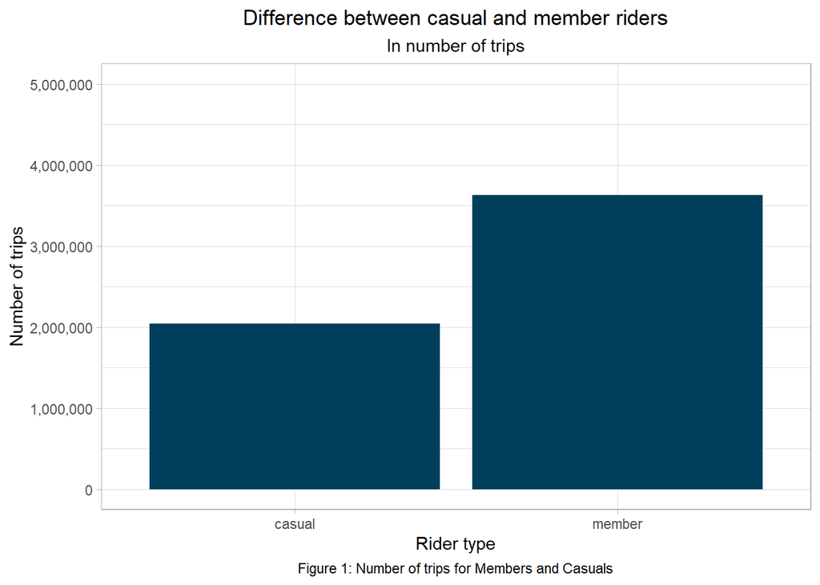

```r
ggplot(data = all_in_one) + geom_bar(mapping = aes(x=member_casual), fill="#003f5c")+
  scale_y_continuous(labels = scales::label_comma(), limits = c(0,5000000))+
  labs(x='Rider type',y='Number of trips',
       title = "Difference between casual and member riders",
       subtitle = "In number of trips",
       caption = "Figure 1: Number of trips for Members and Casuals")+
  theme_light()+
  theme(plot.title = element_text(hjust = 0.5),
        plot.subtitle = element_text(hjust = 0.5),
        plot.caption = element_text(hjust = 0.5))
```

- There are more members than casuals in the dataset.

Average time of trips for `Members` and `Casuals`

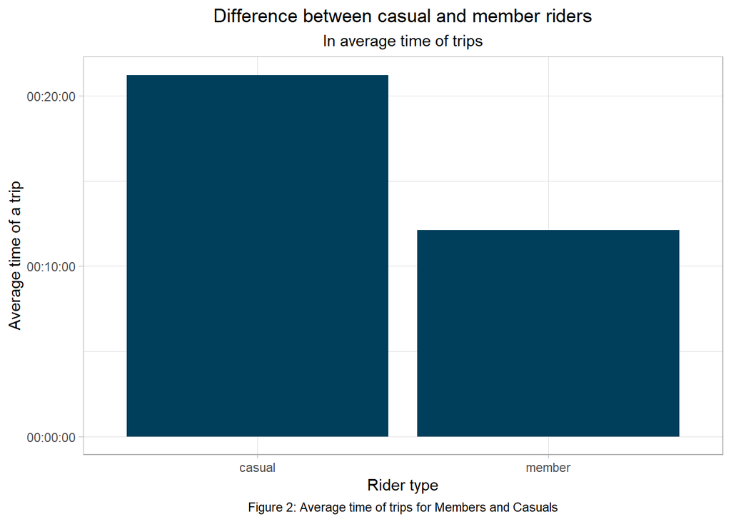

```r
ggplot(data = all_in_one, mapping = aes(x=member_casual, y= ride_length)) +
  geom_bar(fun = "mean", stat = "summary", fill="#003f5c")+
  labs(x='Rider type',y='Average time of a trip',
       title = "Difference between casual and member riders",
       subtitle = "In average time of trips",
       caption = "Figure 2: Average time of trips for Members and Casuals")+
  theme_light()+
  theme(plot.title = element_text(hjust = 0.5),
        plot.subtitle = element_text(hjust = 0.5),
        plot.caption = element_text(hjust = 0.5))
```

- Members have less average trip time than casuals.

To add more depth to it, we’ll add `rideable_type` as part of the bar

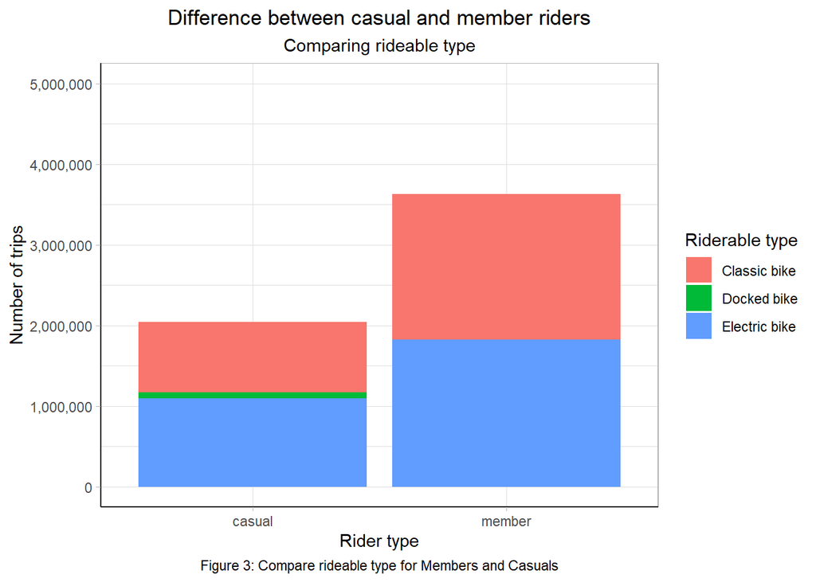

```r
ggplot(data = all_in_one) + geom_bar(mapping = aes(x=member_casual, fill = rideable_type)) +
  scale_y_continuous(labels = scales::label_comma(), limits = c(0,5000000))+
  labs(x='Rider type',y='Number of trips',
       title = "Difference between casual and member riders",
       subtitle = "Comparing rideable type",
       caption = "Figure 3: Compare rideable type for Members and Casuals")+
  theme_light()+
  theme(plot.title = element_text(hjust = 0.5),
        plot.subtitle = element_text(hjust = 0.5),
        axis.line = element_line(colour = "black"),
        plot.caption = element_text(hjust = 0.5))+
  guides(fill=guide_legend(title="Riderable type"))+
  scale_fill_discrete(breaks =c("classic_bike", "docked_bike", "electric_bike"), labels=c("Classic bike", "Docked bike", "Electric bike"))
```

Percentage of number of rides per `day_of_week` **(Pie chart)**

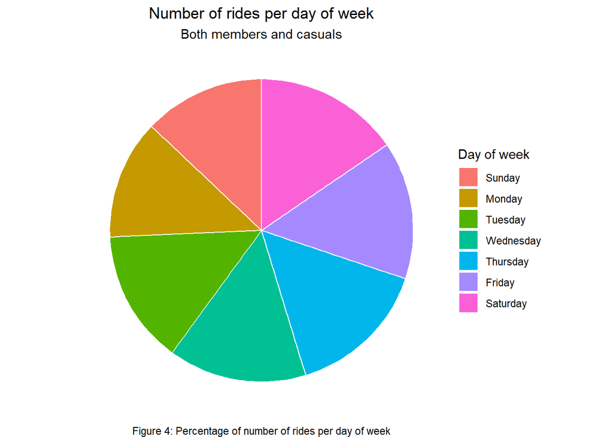

```r
ggplot(all_in_one, aes(x = factor(1), fill = factor(day_of_week))) + geom_bar(width = 1,color="white")+
  coord_polar(theta = "y")+
  theme_void() +
  labs(title = "Number of rides per day of week", fill = "Day of week",
       subtitle = "Both members and casuals",
       caption = "Figure 4: Percentage of number of rides per day of week")+
  theme(plot.title = element_text(hjust = 0.5),
        plot.subtitle = element_text(hjust = 0.5),
        plot.caption = element_text(hjust = 0.5))+
  scale_fill_discrete("Day of week",breaks=c("1","2","3","4","5","6","7"),labels=c("Sunday","Monday","Tuesday","Wednesday","Thursday","Friday","Saturday"))
```

Save the `day_of_week` column in a new table to create a line chart

```r
counted_data <- all_in_one$day_of_week |>
  table() |>
  as.data.frame()
```

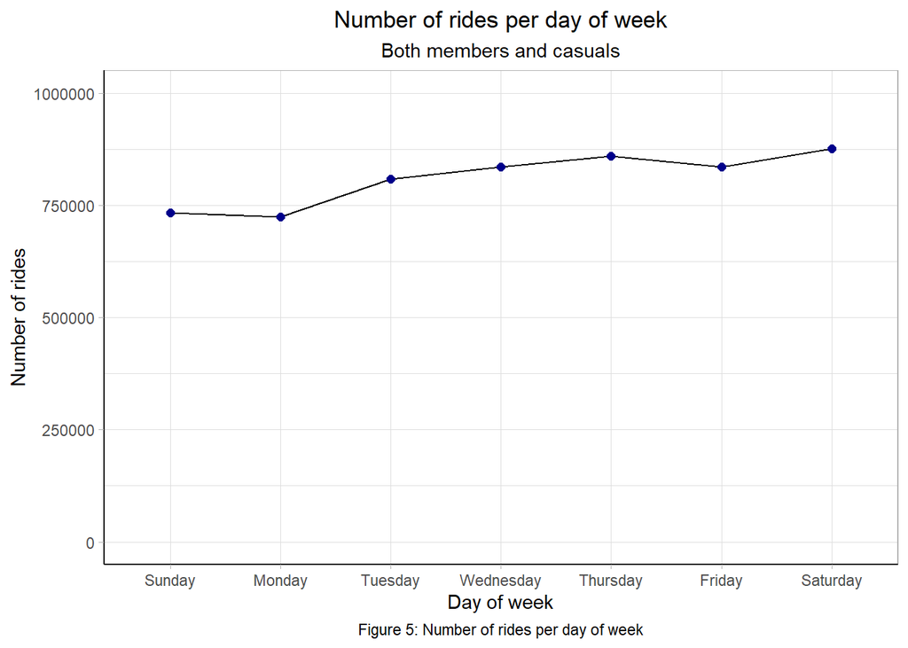

```r
ggplot(counted_data,aes(x=Var1,y=Freq))+
  geom_line(group=1)+
  geom_point(size = 2, color = "darkblue")+
  scale_linetype(name='Tree',breaks=1:5)+
  scale_shape(name='Tree',breaks=1:5)+
  scale_y_continuous(limits = c(0,1000000))+
  labs(x='Count',y='Number of rides',
       title='Number of rides per day of week',
       subtitle='Both members and casuals',
       caption = "Figure 5: Number of rides per day of week")+
  theme_light()+
  theme(plot.title = element_text(hjust = 0.5),
        plot.subtitle = element_text(hjust = 0.5),
        axis.line = element_line(colour = "black"),
        plot.caption = element_text(hjust = 0.5))+
  scale_x_discrete("Day of week",breaks=c("1","2","3","4","5","6","7"),labels=c("Sunday","Monday","Tuesday","Wednesday","Thursday","Friday","Saturday"))
```

Split the dataset into two tables, one for `Members` and one for `Casuals`

```r
counted_data_members <- dplyr::filter(all_in_one, grepl('member', member_casual))
counted_data_members <- counted_data_members$day_of_week |>
  table() |>
  as.data.frame()

counted_data_casuals <- dplyr::filter(all_in_one, grepl('casual', member_casual))
counted_data_casuals <- counted_data_casuals$day_of_week |>
  table() |>
  as.data.frame()

summary(counted_data_members) # Number of Member rows 3,630,818
```

```
##  Var1       Freq
##  1:1   Min.   :401907
##  2:1   1st Qu.:479747
##  3:1   Median :525249
##  4:1   Mean   :518688
##  5:1   3rd Qu.:577269
##  6:1   Max.   :589631
##  7:1
```

```r
summary(counted_data_casuals) # Number of Casual rows 2,043,631
```

```
##  Var1       Freq
##  1:1   Min.   :233183
##  2:1   1st Qu.:245256
##  3:1   Median :269991
##  4:1   Mean   :291947
##  5:1   3rd Qu.:320867
##  6:1   Max.   :408212
##  7:1
```

Number of rides per `day_of_week` for `Members`

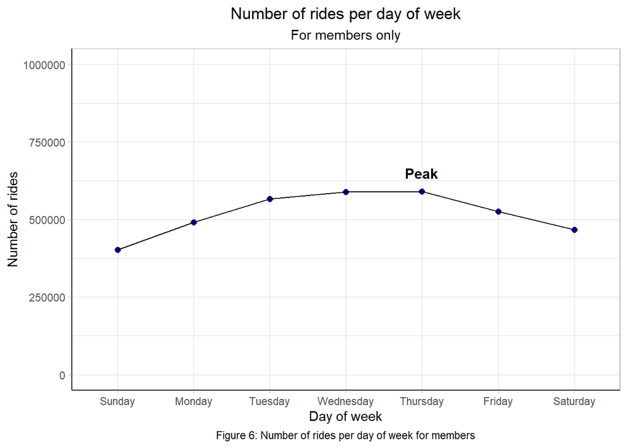

```r
ggplot(counted_data_members,aes(x=Var1,y=Freq))+
  geom_point(size = 2, color = "darkblue")+
  geom_line(group=1)+
  scale_linetype(name='Tree',breaks=1:5)+
  scale_shape(name='Tree',breaks=1:5)+
  scale_y_continuous(limits = c(0,1000000))+
  labs(x='Count',y='Number of rides',
       title='Number of rides per day of week',
       subtitle='For members only',
       caption = "Figure 6: Number of rides per day of week for members")+
       annotate("text",size=4, color = "black", x=5, y=650000, fontface = "bold", label = "Peak")+
  theme_light()+
  theme(plot.title = element_text(hjust = 0.5),
        plot.subtitle = element_text(hjust = 0.5),
        axis.line = element_line(colour = "black"),
        plot.caption = element_text(hjust = 0.5))+
  scale_x_discrete("Day of week",breaks=c("1","2","3","4","5","6","7"),labels=c("Sunday","Monday","Tuesday","Wednesday","Thursday","Friday","Saturday"))
```

Number of rides per `day_of_week` for `Casuals`

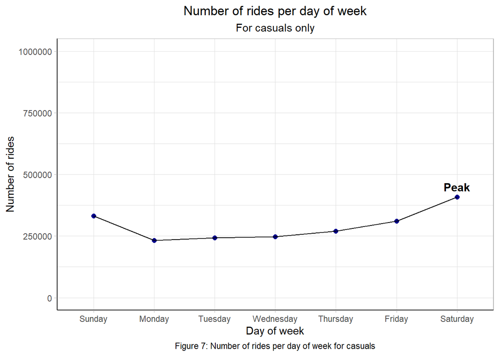

```r
ggplot(counted_data_casuals,aes(x=Var1,y=Freq))+
  geom_point(size = 2, color = "darkblue")+
  geom_line(group=1)+
  scale_linetype(name='Tree',breaks=1:5)+
  scale_shape(name='Tree',breaks=1:5)+
  scale_y_continuous(limits = c(0,1000000))+
  labs(x='Count',y='Number of rides',
       title='Number of rides per day of week',
       subtitle='For casuals only',
       caption = "Figure 7: Number of rides per day of week for casuals")+
  annotate("text",size=4, color = "black", x=7, y=450000, fontface = "bold", label = "Peak")+
  theme_light()+
  theme(plot.title = element_text(hjust = 0.5),
        plot.subtitle = element_text(hjust = 0.5),
        axis.line = element_line(colour = "black"),
        plot.caption = element_text(hjust = 0.5))+
  scale_x_discrete("Day of week",breaks=c("1","2","3","4","5","6","7"),labels=c("Sunday","Monday","Tuesday","Wednesday","Thursday","Friday","Saturday"))
```

- Members have more rides during the weekdays, while casuals have more during the weekends.

Comparison between the number of rides per `month` for both `Members` and `Casuals`

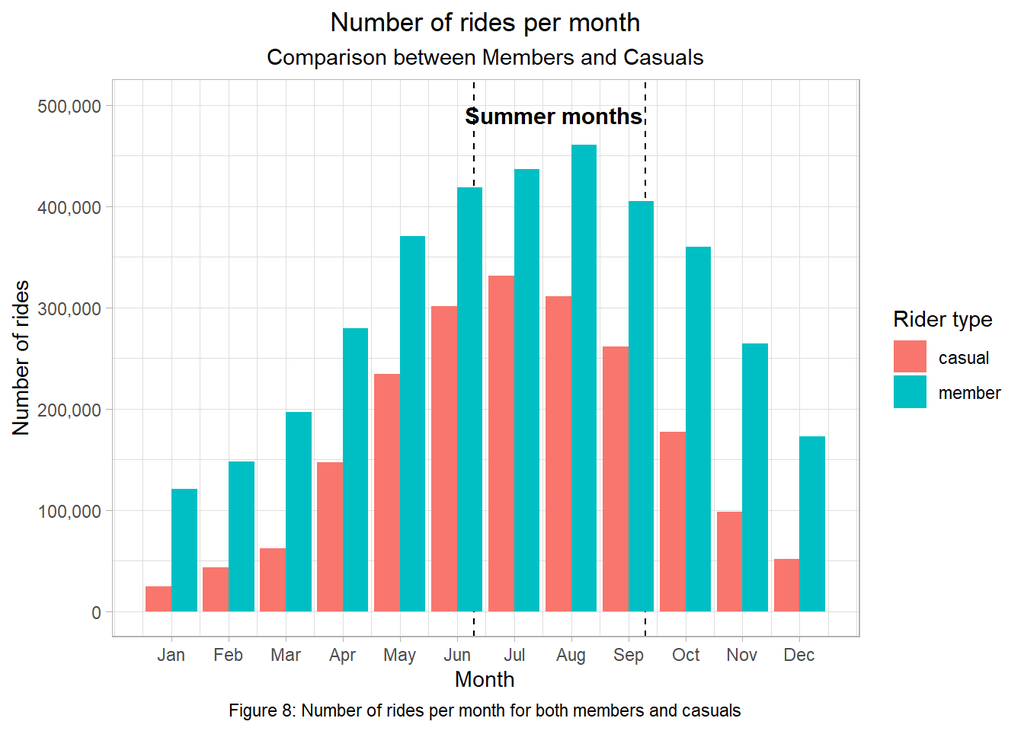

```r
ggplot(all_in_one, aes(as.numeric(month_of_ride), fill = member_casual)) +
  geom_vline(xintercept=c(6.3,9.3), linetype="dashed", color = "black")+
  geom_bar(position = position_dodge(preserve = "single")) +
  scale_x_continuous(breaks = 1:12, labels=c("Jan", "Feb", "Mar", "Apr", "May", "Jun", "Jul", "Aug", "Sep", "Oct", "Nov", "Dec"))+
  scale_y_continuous(limits = c(0,500000), labels = scales::label_comma())+
  labs(x='Month',y='Number of rides',
       title='Number of rides per month',
       subtitle='Comparison between Members and Casuals',
       caption = "Figure 8: Number of rides per month for both members and casuals")+
  annotate("text",size=4, color = "black", x=7.7, y=490000, fontface = "bold", label = "Summer months")+
  theme_light()+
  theme(plot.title = element_text(hjust = 0.5),
        plot.subtitle = element_text(hjust = 0.5),
        plot.caption = element_text(hjust = 0.5))+
  guides(fill=guide_legend(title="Rider type"))
```

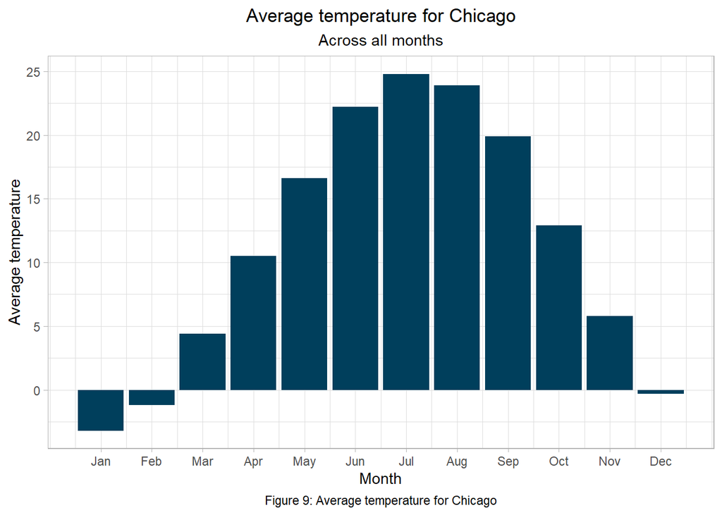

```r
avg_temp <- c(-3.2, -1.2, 4.4, 10.5, 16.6, 22.2, 24.8, 23.9, 19.9, 12.9, 5.8, -0.3)
month <- c(1,2,3,4,5,6,7,8,9,10,11,12)
data.frame(month, avg_temp) %>%
    ggplot(aes(x=month, y=avg_temp)) +
    geom_col(fill = "#003f5c") +
  scale_x_continuous(breaks = 1:12, labels=c("Jan", "Feb", "Mar", "Apr", "May", "Jun", "Jul", "Aug", "Sep", "Oct", "Nov", "Dec"))+
    labs(x="Month", y="Average temperature",
         title="Average temperature for Chicago",
         subtitle = "Across all months",
         caption = "Figure 9: Average temperature for Chicago")+
  theme_light()+
  theme(plot.title = element_text(hjust = 0.5),
        plot.caption = element_text(hjust = 0.5),
        plot.subtitle = element_text(hjust = 0.5))
```

Creating a table that shows stats about each `start_hour`

```r
all_in_one %>%
    group_by(start_hour) %>%
    summarise(count = length(ride_id),
          'Percentage' = format(round((length(ride_id) / nrow(all_in_one)) * 100, 2), nsmall = 2),
          'members_percentage' = (sum(member_casual == "member") / length(ride_id)) * 100,
          'casual_percentage' = (sum(member_casual == "casual") / length(ride_id)) * 100,
          'percentage_differance' = members_percentage - casual_percentage)
```

```
## # A tibble: 24 × 6
##    start_hour  count Percentage members_percentage casual_percentage
##         <int>  <int> <chr>                   <dbl>             <dbl>
##  1          0  71637 1.26                     48.9              51.1
##  2          1  44723 0.79                     46.9              53.1
##  3          2  26336 0.46                     45.7              54.3
##  4          3  15794 0.28                     50.0              50.0
##  5          4  14608 0.26                     60.0              40.0
##  6          5  45332 0.80                     75.1              24.9
##  7          6 134389 2.37                     77.9              22.1
##  8          7 245632 4.33                     78.7              21.3
##  9          8 312428 5.51                     77.6              22.4
## 10          9 232824 4.10                     70.2              29.8
## # ℹ 14 more rows
## # ℹ 1 more variable: percentage_differance <dbl>
```

Number of trips per `start_hour`

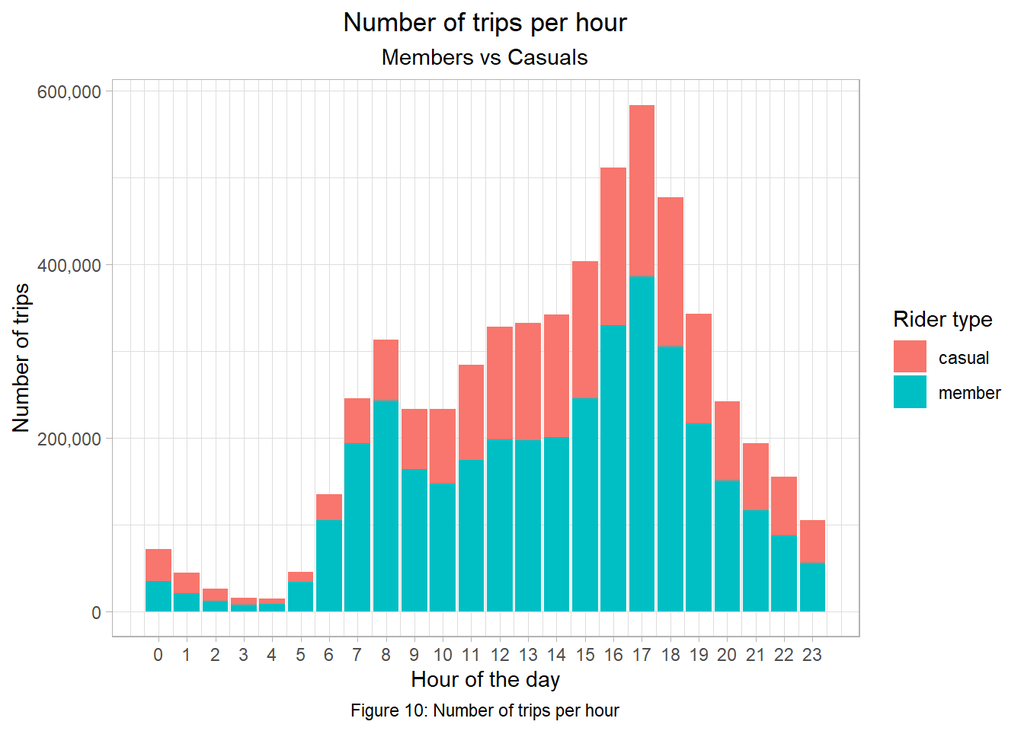

```r
ggplot(all_in_one,aes(start_hour, fill=member_casual)) +
  geom_bar()+
  scale_x_continuous(breaks = 0:23)+
  scale_y_continuous(labels = scales::label_comma())+
    labs(x="Hour of the day", y = "Number of trips", title="Number of trips per hour",
         subtitle = "Members vs Casuals",
         caption = "Figure 10: Number of trips per hour")+
  theme_light()+
  theme(plot.title = element_text(hjust = 0.5),
        plot.caption = element_text(hjust = 0.5),
        plot.subtitle = element_text(hjust = 0.5))+
  guides(fill=guide_legend(title="Rider type"))
```

- Afternoon time has the highest number of trips.
- At 7-9 o’clock we have higher number of trips for members than the next couple of hours, this could relate to members going to work or having a morning bike-ride.
- Lowest number of trips appear after midnight.

### Guiding questions

**Were you able to answer the question of how annual members and casual riders use Cyclistic bikes differently?**

Yes, I believe that we have some understanding of how both annual members and casual riders use Cyclistic bikes differently.

**How do your findings relate to your original question?**

We were able to differentiate between the annual members and casual riders, and have a clear understanding of how they behave.

**Who is your audience? What is the best way to communicate with them?**

My audience are: The director of marketing, Cyclistic marketing analytics team, Cyclistic executive team, the best way to communicate is through presentation.

**Can data visualization help you share your findings?**

Data visualization is the perfect way to share what you have discovered from the data with your audience.

**Is your presentation accessible to your audience?**

Yes, all presentation components are made available.

As a last step in the share phase, I’ll be creating a PowerPoint presentation to share my findings with the stakeholders.

## Act

In this phase the marketing team would act upon the top three recommendations that I’ll provide.

[output not shown]

### Guiding questions

**What is your final conclusion based on your analysis?**  
Both members and casuals have different habits with using the bikes.  
**How could your team and business apply your insights?**  
They could use the insights to turn casual users into members.  
**What next steps would you or your stakeholders take based on your findings?**  
Conduct further analysis to improve the findings, and create a marketing campaign.  
**Is there additional data you could use to expand on your findings?**  
* Information about the users * Data about the weather * Distance between start and end location

### Top three recommendations

- Increase benefits of using the bikes during the winter.
- Create advertisement campaign to encourage people to go to work using bikes.
- Add a miles counting system and give users discounts and free trips to encourage them to use the bikes more.

## Conclusion

This was an amazing experience to have, from the start I felt attached to it and I found myself wanting to learn more and do more, although it took more than I though it would, but it was all because I tried to make a prefect first case study, well as you can see it’s not perfect at all, it’s full of mistakes and fails and many many many searches on Stack overflow, but at least the journey was good and it’s only getting better from here. I want to thank whoever is reading this, I put a lot of effort and time into this project and I hope you liked it, if you have any suggestions or notes please don’t hesitate to contact me. And before I forget I want to give a big thank you to [JHELISON GABRIEL LIMA UCHOA](https://www.kaggle.com/jhelisonuchoa) from Kaggle, his way of approaching this case study helped me a lot and opened my mind to new things.